# Homework 5

Tyler Smith

April 6, 2020

# Problem 1

```r
library(dplyr)
library(tidyr)
library(lubridate)
#Problem 1
liq <- readr::read_csv("liquor.csv")
```

# Problem 2

```r
#Problem 2
#Remove NA Values
liq2 <- na.omit(liq)

#Separates into Latitude and Longitude
liq2 <- liq2 %>%
  separate(col=`Store Location`,into=c("point","coord"),sep="\\(")
liq2 <- liq2 %>%
  separate(col=coord,into=c("Lat","Long"),sep=" ")

#Correctly Format Variables
liq2$Long <- substr(liq2$Long,1,nchar(liq2$Long)-1)
liq2 <- liq2 %>%
  select(-`Invoice/Item Number`,-point) %>%
  mutate(Lat=as.numeric(Lat),Long=as.numeric(Long))

liq2 <- liq2 %>%
  mutate(Date=mdy(Date))

#Extract Year, Month and Date from the date variable
liq2 <- liq2 %>%
  mutate(Year = year(Date),Month=month(Date),Day=day(Date))
```

Above are all the requested data cleanings, eventually recapped in the liq2 dataset.

# Problem 3

[figure not shown]

```r
library(ggplot2)
# Problem 3
#Scatterplot of Lat/Long
ggplot(data=liq2,aes(y=Long,x=Lat))+geom_point()+labs(y="Latitude",x="Longitude",title="Scatterplot of Latitude and Longitude")
```

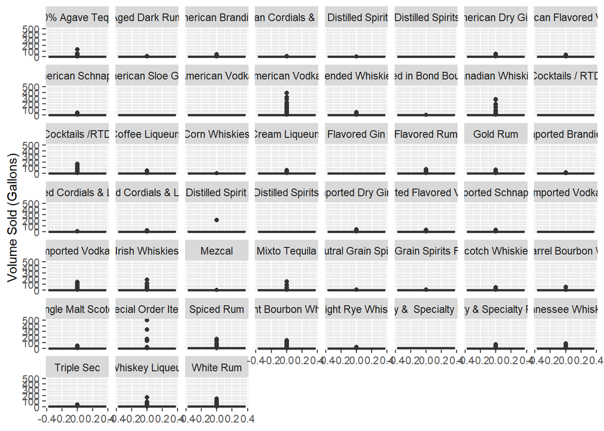

```r
#geom_text(aes(label=substr(`Store Name`,1,5)))

#Breakdown of Liquor Category
liq2 %>%
  ggplot(aes(y=`Volume Sold (Gallons)`))+geom_boxplot()+facet_wrap(~`Category Name`)
```

For the plot above to look right, it needed to be put into the console. It does provide the requested breakdown in this manner, with each type of liquor represented and scale by volume is able to be viewed for each.

We see that American Vodkas are among the most sold, along with special order items. Candadian whiskies, Bourbourn, Irish Whiskies, Tequila, Rum and Whiskey liqueur are all big sellers, with over 100 gallons sold.

# Problem 4

```r
daily  <- liq2 %>%
  group_by(Month,Day) %>%
  summarize(number=n(),volume=sum(`Volume Sold (Gallons)`),money = sum(`Sale (Dollars)`))
head(daily)
```

| Month | Day | number | volume | money |
| --- | --- | --- | --- | --- |
| 1 | 3 | 767 | 1301.78 | 83303.72 |
| 1 | 4 | 143 | 330.97 | 16765.81 |
| 1 | 9 | 701 | 1479.84 | 82539.72 |
| 1 | 10 | 2 | 35.65 | 1457.28 |
| 1 | 11 | 153 | 273.31 | 14426.84 |
| 1 | 16 | 632 | 1779.00 | 95180.40 |

```r
summary(daily)
```

```
##      Month             Day            number          volume
##  Min.   : 1.000   Min.   : 1.00   Min.   :  1.0   Min.   :   0.19
##  1st Qu.: 4.250   1st Qu.: 8.00   1st Qu.: 54.0   1st Qu.:  63.09
##  Median : 7.000   Median :15.00   Median :233.0   Median : 815.26
##  Mean   : 7.021   Mean   :15.69   Mean   :330.0   Mean   : 873.33
##  3rd Qu.:10.000   3rd Qu.:23.75   3rd Qu.:596.2   3rd Qu.:1299.62
##  Max.   :12.000   Max.   :31.00   Max.   :997.0   Max.   :3469.35
##      money
##  Min.   :    18.75
##  1st Qu.:  4721.07
##  Median : 47375.93
##  Mean   : 50499.58
##  3rd Qu.: 82759.06
##  Max.   :218546.47
```

Above is the data set featuring daily liquor sales. We can see the breakdown of each of the variables presented above with the summary function.

# Problem 5

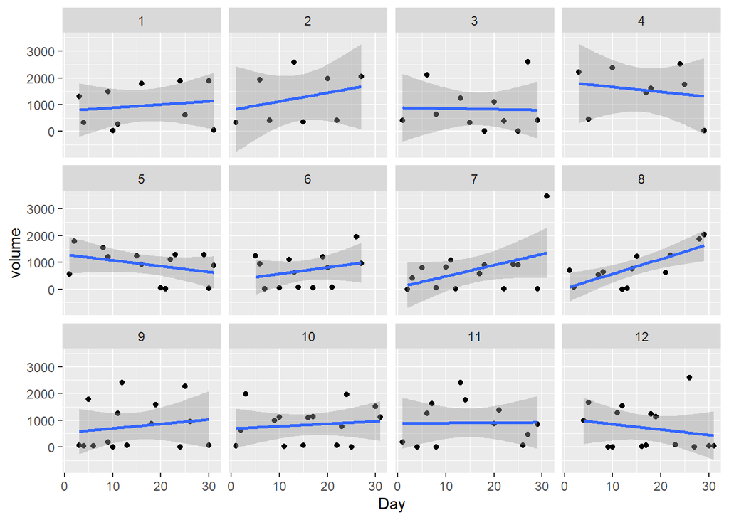

```r
daily %>%
  ggplot(aes(x=Day,y=volume))+geom_point()+geom_smooth(method="lm")+facet_wrap(~Month)
```

From the plot above, we can see that there is a sharp increase towards the end of August. In general, it appears that when students arrive back on campus, the alcohol sales increase. I don’t see a consistent increase or decrease for the other ones with increases. There are two significant decreasaes in May and December, which likely correlates with students leaving for break.

# Problem 6